# Module_3_Technique Practice

Ashna Solkar

2025-04-26

1. Environment Reset Code

```r
rm(list = ls())
```

2. Loading Libraries

```r
library(readr)
library(dplyr)
```

```r
library(ggplot2)
library(factoextra)
library(cluster)
```

3. Loading Data set

```r
data <- read_csv("Employee_Salaries_2019_to_2024.csv")
# Structure and Summary of the dataset
str(data)
```

```
## spc_tbl_ [57,075 × 9] (S3: spec_tbl_df/tbl_df/tbl/data.frame)
##  $ Department     : chr [1:57075] "ABS" "CUS" "DGS" "CEX" ...
##  $ Department Name: chr [1:57075] "Alcohol Beverage Services" "Community Use of Public Facilities" "Department of General Services" "Offices of the County Executive" ...
##  $ Division       : chr [1:57075] "ABS 85 IT Administration" "CUS 70 Finance and Administrative Support Team" "DGS 36 Fleet Management Services" "CEX 15 Chief Administrative Officer's Office" ...
##  $ Gender         : chr [1:57075] "M" "F" "F" "F" ...
##  $ Base Salary    : num [1:57075] 169555 141877 87523 207000 91392 ...
##  $ Overtime Pay   : num [1:57075] 0 0 748 0 0 ...
##  $ Longevity Pay  : num [1:57075] 0 0 2701 0 5733 ...
##  $ Grade          : chr [1:57075] "M3" "M3" "16" "EX2" ...
##  $ Year           : num [1:57075] 2024 2024 2024 2024 2024 ...
##  - attr(*, "spec")=
##   .. cols(
##   ..   Department = col_character(),
##   ..   `Department Name` = col_character(),
##   ..   Division = col_character(),
##   ..   Gender = col_character(),
##   ..   `Base Salary` = col_double(),
##   ..   `Overtime Pay` = col_double(),
##   ..   `Longevity Pay` = col_double(),
##   ..   Grade = col_character(),
##   ..   Year = col_double()
##   .. )
##  - attr(*, "problems")=<externalptr>
```

```r
summary(data)
```

```
##   Department        Department Name      Division            Gender
##  Length:57075       Length:57075       Length:57075       Length:57075
##  Class :character   Class :character   Class :character   Class :character
##  Mode  :character   Mode  :character   Mode  :character   Mode  :character
##
##
##
##   Base Salary      Overtime Pay    Longevity Pay      Grade
##  Min.   :  4816   Min.   :     0   Min.   :    0   Length:57075
##  1st Qu.: 63932   1st Qu.:     0   1st Qu.:    0   Class :character
##  Median : 82998   Median :   631   Median :    0   Mode  :character
##  Mean   : 85754   Mean   :  7374   Mean   : 1111
##  3rd Qu.:103034   3rd Qu.:  8394   3rd Qu.:    0
##  Max.   :306900   Max.   :261311   Max.   :20957
##       Year
##  Min.   :2019
##  1st Qu.:2020
##  Median :2022
##  Mean   :2022
##  3rd Qu.:2023
##  Max.   :2024
```

```r
# Checking parsing problems
problems(data)
```

| row | col | expected | actual | file |
| --- | --- | --- | --- | --- |

The output returns nothing, hence its safe to state that file is clean.

1. Analyzing Grade variable

```r
# Replacing "NULL" with "Unknown" in the Grade column
data$Grade <- ifelse(data$Grade == "NULL", "Unknown", data$Grade)

# Understanding the Grades list
grade_list <- sort(unique(data$Grade))
grade_list
```

```
##   [1] "0"       "10"      "11"      "12"      "13"      "14"      "15"
##   [8] "16"      "17"      "18"      "19"      "20"      "21"      "22"
##  [15] "23"      "24"      "25"      "26"      "27"      "28"      "29"
##  [22] "30"      "31"      "32"      "33"      "34"      "35"      "36"
##  [29] "38"      "39"      "40"      "5"       "7"       "8"       "9"
##  [36] "A1"      "A2"      "A3"      "B1"      "B2"      "B2P"     "B3"
##  [43] "B4"      "B6"      "C1"      "C2"      "C3"      "C4"      "C5"
##  [50] "C6"      "D1"      "D2"      "D3"      "D4"      "EX0"     "EX1"
##  [57] "EX2"     "EX3"     "F1"      "F2"      "F2P"     "F3"      "F3P"
##  [64] "F4"      "G1"      "G2"      "G3"      "G4"      "IG1"     "LB1"
##  [71] "LB2"     "LB3"     "M1"      "M2"      "M3"      "MD2"     "MD3"
##  [78] "MD4"     "N12"     "N13"     "N14"     "N15"     "N16"     "N17"
##  [85] "N18"     "N19"     "N20"     "N21"     "N22"     "N23"     "N24"
##  [92] "N25"     "N26"     "N27"     "N28"     "N29"     "N30"     "N31"
##  [99] "N32"     "N33"     "N34"     "N35"     "N36"     "N38"     "N39"
## [106] "N40"     "N5"      "P1"      "P2"      "P3"      "P4"      "P4P"
## [113] "P5"      "S1"      "S2"      "S3"      "S5"      "S6"      "T1"
## [120] "T1P"     "T2"      "Unknown"
```

```r
# Grouping Salaries by Grade Year-wise (Assuming the Government has centralized HR)
base_pay_grade <-  data %>%
  group_by(Year, Department, Grade) %>%
  summarise(Average = mean(`Base Salary`), Median = median(`Base Salary`), Min = min(`Base Salary`), Max = max(`Base Salary`), Mode = names(which.max(table(`Base Salary`))), .groups = "drop") %>%
  arrange(desc(Year), desc(Median))
base_pay_grade
```

| Year | Department | Grade | Average | Median | Min | Max | Mode |
| --- | --- | --- | --- | --- | --- | --- | --- |
| 2024 | CEX | EX0 | 306900.000 | 306900.000 | 306900.00 | 306900.00 | 306900 |
| 2024 | CAT | EX1 | 258000.000 | 258000.000 | 258000.00 | 258000.00 | 258000 |
| 2024 | POL | EX1 | 254000.000 | 254000.000 | 250000.00 | 258000.00 | 250000 |
| 2024 | DOT | EX1 | 250000.000 | 250000.000 | 250000.00 | 250000.00 | 250000 |
| 2024 | HHS | EX1 | 250000.000 | 250000.000 | 250000.00 | 250000.00 | 250000 |
| 2024 | DGS | EX1 | 246000.000 | 246000.000 | 246000.00 | 246000.00 | 246000 |
| 2024 | ABS | EX1 | 240000.000 | 240000.000 | 240000.00 | 240000.00 | 240000 |
| 2024 | FIN | EX1 | 240000.000 | 240000.000 | 240000.00 | 240000.00 | 240000 |
| 2024 | FRS | EX1 | 240000.000 | 240000.000 | 240000.00 | 240000.00 | 240000 |
| 2024 | OMB | EX1 | 240000.000 | 240000.000 | 240000.00 | 240000.00 | 240000 |

[output cut: 3485 more lines]

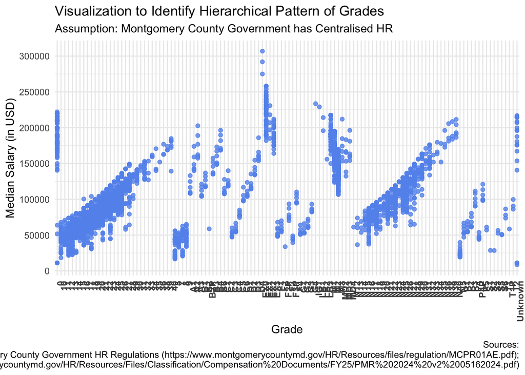

```r
# Visualizing to reveal the hierarchy of grades
ggplot(base_pay_grade, aes(x= Grade, y = Median)) +
  geom_point(color="cornflowerblue", alpha = 0.8)+
  theme_minimal()+
  theme(axis.text.x = element_text(angle = 90, hjust = 1, face = "bold")) +
  scale_y_continuous(breaks= seq(0,307000,50000)) +
  labs(title = "Visualization to Identify Hierarchical Pattern of Grades",
       subtitle = "Assumption: Montgomery County Government has Centralised HR",
       x = "Grade",
       y = "Median Salary (in USD)",
       caption = "Sources:\n Montgomery County Government HR Regulations (https://www.montgomerycountymd.gov/HR/Resources/files/regulation/MCPR01AE.pdf);\n Pay Grade and Salary Distribution (https://www.montgomerycountymd.gov/HR/Resources/Files/Classification/Compensation%20Documents/FY25/PMR%202024%20v2%2005162024.pdf)")
```

The scatterplot shows very clearly, stepwise increase in Median Salary by Grade. Moreover, with the help of sources sited in the visual: Montgomery HR Regulations: Defines Grades as standardized level assigned based on classification. Pay Grade and Salary Distribution: Lists Pay Grades explicitly.

According to the Montgomery County Government HR Regulations (Section II, Classification Process, Page 6), “A grade designates a salary range on a County Government salary schedule which applies to classes of positions. Although different with respect to kinds of work, classes assigned to the same grade are considered equivalent in value as determined by their evaluations under QES III.” This supports the conclusion that while job duties and work types may vary across departments, the grade structure serves as a standardized framework controlling compensation across the organization. Therefore, analyzing compensation patterns at the grade level — irrespective of department — is a justified approach for understanding salary distributions and employee classification within the County Government.

Therefore, we can say that Montgomery County Government likely uses a centralized HR system for salary schedules, where Grades control pay levels across departments, even if work types vary.

```r
# Untraceable Grades
grades_wise <- data %>%
  group_by(Grade, Department) %>%
  summarise("Number_of_Employees"=n(), .groups = "drop") %>%
  arrange(Department, Grade, desc(Number_of_Employees))

grades_not_found <- filter(grades_wise, Grade %in% c("B2P", "F2P", "F3P", "MD2", "MD3", "MD4", "P4P", "T1P"))
```

During the analysis, eight Grades (B2P, F2P, F3P, MD2, MD3, MD4, P4P, T1P) were identified that could not be traced to the official Montgomery County Government salary schedules or compensation documents. These discrepancies may result from typographical errors, internally designated grades not disclosed publicly, or classifications specific to certain specialized departments. Accordingly, while the broader analysis assumes a centralized HR structure based on available documentation, these Grades have been flagged for separate review, and caution is advised when interpreting results involving these cases.

2. Preparing for Clustering

2.1. Clustering Year-wise

Salaries naturally increase each year due to inflation, promotions, or appraisals. If data from multiple years (2019 to 2024) were combined without separation, clustering would distinguish employees by year instead of identifying meaningful patterns in salary structure. Therefore, analyzing each year independently will provide more accurate and comparable basis for discovering standardized grade groupings across employees.

```r
# Filtering data for 2024
data_2024 <- data %>%
  filter(Year == 2024)
```

2.2. Removing Categorical Columns

Selecting purely numeric variables because k-means clustering uses Euclidean distance. In this case, compensation components such as Base Salary, Overtime Pay, and Longevity Pay are used.

```r
# Removing categorical columns
cluster_data <- data_2024[,5:7]
```

2.3. Scaling the Data

scale() standardizes (z-score) each column in ‘data’ by subtracting the mean and dividing the resultant with standard deviation. z=(x-mean)/std deviation. This is an important step before performing clustering because clustering algorithms are sensitive to scale. If one variable has larger numbers, it will dominate the clustering process.

Scaling ensures all features contribute equally.

```r
# Scaling the data
data_scaled <- scale(cluster_data)
```

2.4. Elbow Method

Using elbow method to determine the optimal numbers of clusters (k). The fviz_nbclust() is a function from factoextra package, it visualizes the optimal number of clusters by applying WSS metric.

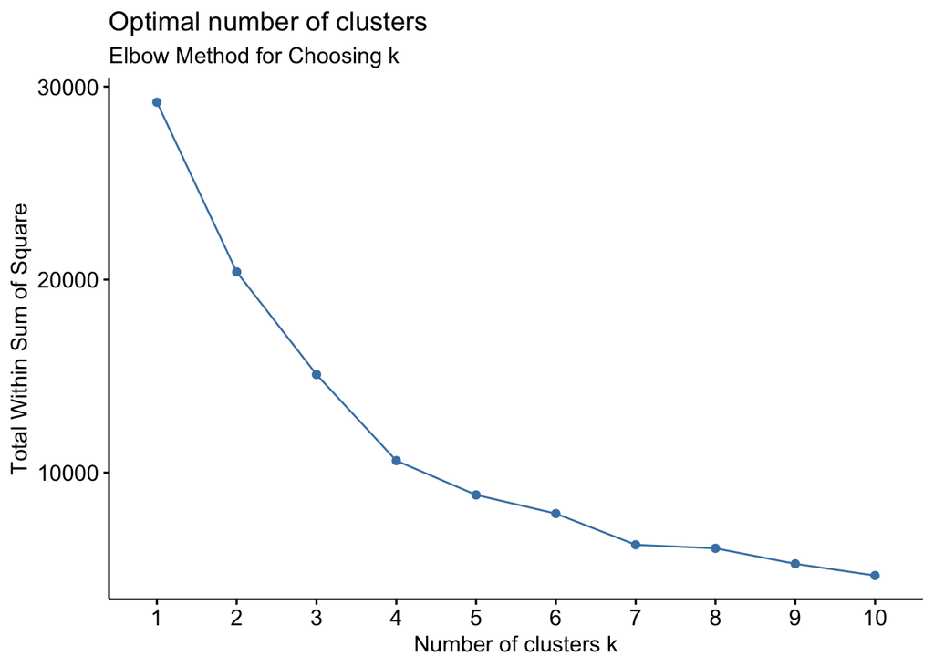

```r
# Using elbow method
fviz_nbclust(data_scaled, kmeans, method = "wss") +
  labs(subtitle = "Elbow Method for Choosing k")
```

In the above elbow plot as k increases, WSS decreases because clusters get smaller and more compact. Around k =3 or 4, the rate of decrease starts to flatten out. Hence, the optimal number of clusters is likely 3 or 4 because WSS drops sharply from k= 1 to k = 3. After k = 4, adding more clusters does not significantly improve the compactness.

Choosing k = 3 or 4 will keep the model simple, provide meaningful segmentation, and avoid overfitting by splitting too much.

Since I wish to focus on more granularity, that is finer differences between compensation structure, choosing k = 4.

2.4. Applying & Visualizing k-means Clustering with 4 Clusters

2.5. Applying and Visualizing k-means Cluster

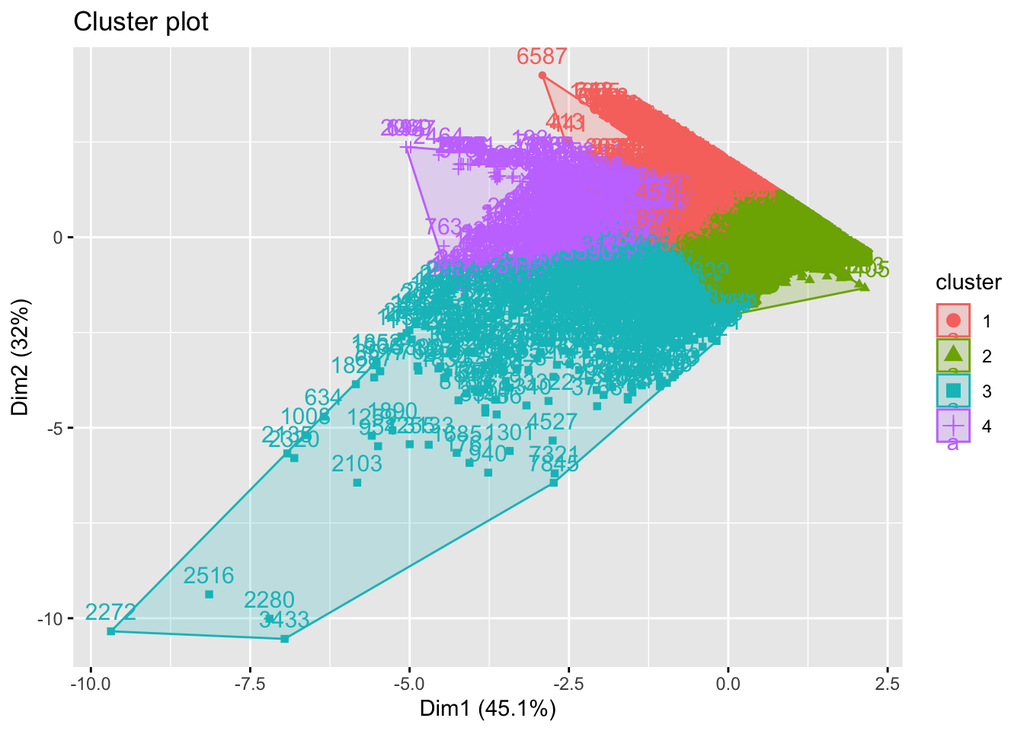

```r
# Applying k-means clustering with 4 clusters
set.seed(123)
km <- kmeans(data_scaled, centers = 4, nstart = 25)

# Visualize the clusters
fviz_cluster(km, data = data_scaled)
```

Using fviz_cluster() from factoextra package we have created a 2D plot that visualizes how data has been grouped into clusters by the k-means algorithm.

```r
# Number of employees in each group
km$size
```

```
## [1] 2225 5529  648 1330
```

Cluster 1 (red) has 2225 employees Cluster 2 (green) has 5529 employees Cluster 3 (blue) has 648 employees Cluster 4 (purple) has 1330 employees

```r
# Adding cluster labels back to data_2024
data_2024$Cluster <- factor(km$cluster)
head(data_2024)
```

| Department | Department Name | Division | Gender | Base Salary | Overtime Pay | Longevity Pay | Grade | Year | Cluster |
| --- | --- | --- | --- | --- | --- | --- | --- | --- | --- |
| ABS | Alcohol Beverage Services | ABS 85 IT Administration | M | 169555.0 | 0.00 | 0.00 | M3 | 2024 | 1 |
| CUS | Community Use of Public Facilities | CUS 70 Finance and Administrative Support Team | F | 141876.9 | 0.00 | 0.00 | M3 | 2024 | 1 |
| DGS | Department of General Services | DGS 36 Fleet Management Services | F | 87523.0 | 748.37 | 2701.48 | 16 | 2024 | 2 |
| CEX | Offices of the County Executive | CEX 15 Chief Administrative Officer's Office | F | 207000.0 | 0.00 | 0.00 | EX2 | 2024 | 1 |
| HHS | Department of Health and Human Services | HHS 60 Office of Eligibility and Support Services | F | 91392.0 | 0.00 | 5733.27 | N17 | 2024 | 4 |
| OAG | Office of Agriculture | OAG 78 Agricultural Services | F | 108899.0 | 0.00 | 3361.18 | N21 | 2024 | 1 |

Recommendations: 1. New hires could be assigned to the most likely compensation cluster based on initial attributes such as Department, Grade, and Base Salary. This will help HR plan budgets and pay equity initiatives. 2. Employees who do not fit into any clusters could be flagged for irregularities in pay. This will be useful for audits or traceback negotiation exceptions, or for pay parity analysis. 3. Performing clustering year-over-year to see if compensation profiles are shifting.